# Capstone 4th Economy

Quan, Yanhao

2022/2/2

```r
library(readxl) #reading excel files
library(tidyverse)
library(mFilter) #Package used for hp filter
```

```r
library(cowplot) #Allows for side by side graphs
library(stringr)#for merge columns to creat a date column
library(haven)
library(lfe)
library(dplyr)
```

#The first part of the project is to check the trend of employment, UI policy, and Covid related data. And I’m on employment data set.

```r
project_path <- "C:/Users/85384/Desktop/Capstone"
setwd(project_path)
lf <- read.csv("emp-unemp.xlsx - Sheet1.csv")
lf2 <- lf[-c(1, 2, 3, 4), -c(2,5,14:17)]
#colnames(lf2) <- lf[4,]
#View(lf2)

new_lf <- na.omit(lf2)


names(new_lf)[names(new_lf) == 'X'] <- 'State'
names(new_lf)[names(new_lf) == 'X.1'] <- 'Year'
names(new_lf)[names(new_lf) == 'X.2'] <- 'Month'
names(new_lf)[names(new_lf) == 'X.4'] <- 'Population'
names(new_lf)[names(new_lf) == 'X.5'] <- 'Labor_Force'
names(new_lf)[names(new_lf) == 'X.6'] <- '%_of_population'
names(new_lf)[names(new_lf) == 'X.7'] <- 'Employed'
names(new_lf)[names(new_lf) == 'Total.E.Number.of.people.in.civilian.labor.force.who.are.employed'] <- '%Emp'
names(new_lf)[names(new_lf) == 'X.8'] <- 'Unemployed'
names(new_lf)[names(new_lf) == 'X.9'] <- 'Unemployed_rate'
names(new_lf)[names(new_lf) == 'X.10'] <- 'Period'
View(new_lf)
is.data.frame(new_lf)
```

```
## [1] TRUE
```

```r
is.numeric(new_lf)
```

```
## [1] FALSE
```

```r
new_lf$State <- as.numeric(new_lf$State)
#new_lf$County <- as.numeric(new_lf$County)
new_lf$early <- ifelse(new_lf$State %in% c('1','2','4','5','12','13','16','18','19','24','28','29','30','31','33','38','39','40','46','45','47','48','49','54','56'),1,0)
new_lf$Employed <- as.numeric(new_lf$Employed)
#delete the "," in the data
#new_lf$Employed <- as.numeric(gsub(",", "",new_lf$Employed))
#new_lf$Civilian_Labor_Force <- as.numeric(gsub(",", "",new_lf$Civilian_Labor_Force))
#new_lf$Unemployed_level <- as.numeric(gsub(",", "",new_lf$Unemployed_level))
View(new_lf)
#class(new_lf1$Civilian_Labor_Force)
class(new_lf$Employed)
```

```
## [1] "numeric"
```

```r
#class(new_lf$Employed)

#library(lubridate)
#new_lf$Period <- my(new_lf$Period)
#format(new_lf$Period, "%Y%m")

#class(new_lf$Period)
```

```r
#lf_states <- new_lf %>% group_by(State,Period) %>%
    #summarise(Emp = sum(Employed),lab_force = sum(Civilian_Labor_Force))
lf_states <- new_lf
lf_states <- filter(lf_states, Year != 2018)
#lf_states$period <- with(lf_states, sprintf("%d-%02d", Year, Month))
lf_states$Period <- as.Date(lf_states$Period,"%Y/%m/%d")
#library(lubridate)
#lf_states$Period <- my(lf_states$period)
#format(lf_states$Period, "%m/%d/%Y")
class(lf_states$Period)
```

```
## [1] "Date"
```

```r
View(lf_states)
```

```r
lf_states <- as.data.frame(lf_states)
#class(new_lf$Labor_Force)
#class(new_lf$Employed)
lf_states$Emp <- as.numeric(lf_states$Emp)
lf_states$lEmp <- log(lf_states$Emp)
#lf_states_6.25 <- hpfilter(lf_states$lEmp , freq = 6.25,type = "lambda")
#lf_states$Emp_T6.25 <- lf_states_6.25$trend
#lf_states$Emp_C6.25 <- lf_states_6.25$cycle

head(lf_states)
```

```
##   State Year Month Population Labor_Force %_of_population Employed %Emp
## 1     1 2019     1    3858512     2229899            57.8  2149188 55.7
## 2     1 2019     2    3859089     2231539            57.8  2153542 55.8
## 3     1 2019     3    3860039     2231949            57.8  2157197 55.9
## 4     1 2019     4    3861170     2231885            57.8  2160522   56
## 5     1 2019     5    3862424     2232174            57.8  2163952   56
## 6     1 2019     6    3863995     2233402            57.8  2167676 56.1
##   Unemployed Unemployed_rate     Period early     Emp     lEmp
## 1      80711             3.6 2019-01-01     1 2149188 14.58060
## 2      77997             3.5 2019-02-01     1 2153542 14.58262
## 3      74752             3.3 2019-03-01     1 2157197 14.58432
## 4      71363             3.2 2019-04-01     1 2160522 14.58586
## 5      68222             3.1 2019-05-01     1 2163952 14.58745
## 6      65726             2.9 2019-06-01     1 2167676 14.58917
```

## Draw two figures.

- On the first, draw the raw data and the secular trend estimate.
- On the second draw the Employment cycle estimate.

#The Trend and cycle for 25 states which ends the UI policy earily#

#Alabama

```r
lf_states1 <- filter(lf_states, Year != 2019, State == 1, early == 1)
lf_states1_6.25 <- hpfilter(lf_states1$lEmp , freq = 6.25,type = "lambda")
lf_states1$Emp_T6.25 <- lf_states1_6.25$trend
lf_states1$Emp_C6.25 <- lf_states1_6.25$cycle
plot1<-ggplot(data=lf_states1,group = 1)+
geom_line(aes(x=Period,y=lEmp,color='Log Employed'),size=1.5) + geom_line(aes(x=Period,y=Emp_T6.25,color='Log Employed Secular'),linetype=2,size=1.5) +xlab("Period")+ylab("")+scale_colour_manual(name="",values=c('Log Employed'='blue','Log Employed Secular'='red'))+ggtitle('Employed Trend')+theme(plot.title = element_text(hjust = 1))

plot2<-ggplot(data=lf_states1)+
geom_line(aes(x=Period,y=Emp_C6.25,color='Log Employed Cycle'),size=1.5,linetype=2)  +xlab("Period")+ylab("")+scale_colour_manual(name="",values=c('Log Employed Cycle'='blue'))+ggtitle('Employed Cycle')+theme(plot.title = element_text(hjust = 1))
```

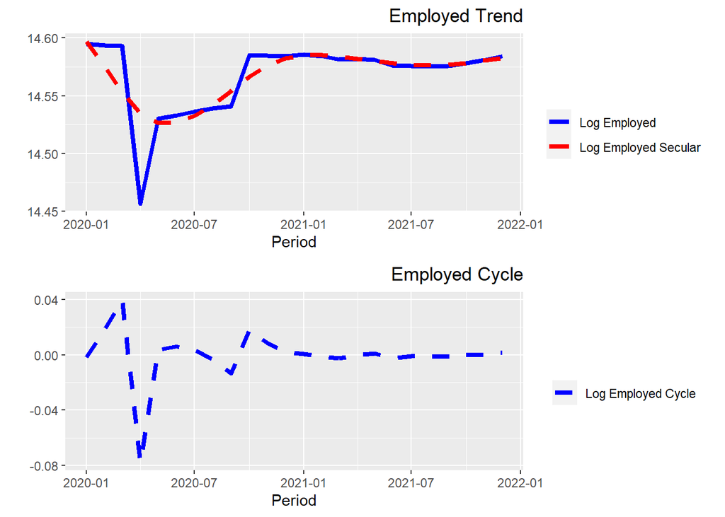

```r
plot_grid(plot1, plot2,ncol = 1,align = 'v')
```

#Alaska

```r
lf_states2 <- filter(lf_states, Year != 2019, State == 2, early == 1)
lf_states2_6.25 <- hpfilter(lf_states2$lEmp , freq = 6.25,type = "lambda")
lf_states2$Emp_T6.25 <- lf_states2_6.25$trend
lf_states2$Emp_C6.25 <- lf_states2_6.25$cycle
plot3<-ggplot(data=lf_states2)+
geom_line(aes(x=Period,y=lEmp,color='Log Employed'),size=1.5) + geom_line(aes(x=Period,y=Emp_T6.25,color='Log Employed Secular'),linetype=2,size=1.5) +xlab("Period")+ylab("")+scale_colour_manual(name="",values=c('Log Employed'='blue','Log Employed Secular'='red'))+ggtitle('Employed Trend')+theme(plot.title = element_text(hjust = 1))

plot4<-ggplot(data=lf_states2)+
geom_line(aes(x=Period,y=Emp_C6.25,color='Log Employed Cycle'),size=1.5,linetype=2)  +xlab("Period")+ylab("")+scale_colour_manual(name="",values=c('Log Employed Cycle'='blue'))+ggtitle('Employed Cycle')+theme(plot.title = element_text(hjust = 1))
```

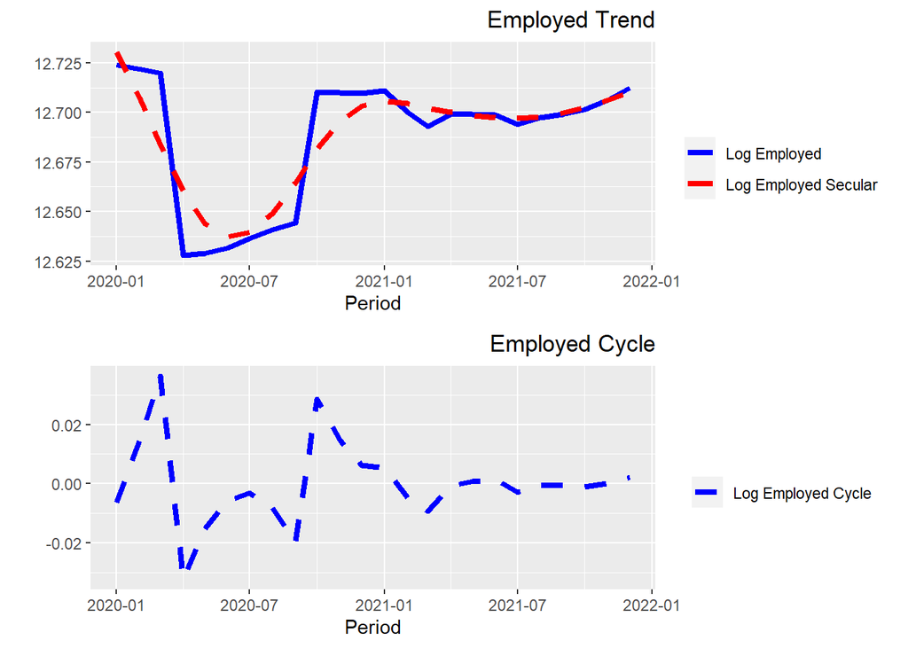

```r
plot_grid(plot3, plot4,ncol = 1,align = 'v')
```

#Arizona

```r
lf_states4 <- filter(lf_states,Year != 2019, State == 4, early == 1)
lf_states4_6.25 <- hpfilter(lf_states4$lEmp , freq = 6.25,type = "lambda")
lf_states4$Emp_T6.25 <- lf_states4_6.25$trend
lf_states4$Emp_C6.25 <- lf_states4_6.25$cycle
plot5<-ggplot(data=lf_states4)+
geom_line(aes(x=Period,y=lEmp,color='Log Employed'),size=1.5) + geom_line(aes(x=Period,y=Emp_T6.25,color='Log Employed Secular'),linetype=2,size=1.5) +xlab("Period")+ylab("")+scale_colour_manual(name="",values=c('Log Employed'='blue','Log Employed Secular'='red'))+ggtitle('Employed Trend')+theme(plot.title = element_text(hjust = 1))

plot6<-ggplot(data=lf_states4)+
geom_line(aes(x=Period,y=Emp_C6.25,color='Log Employed Cycle'),size=1.5,linetype=2)  +xlab("Period")+ylab("")+scale_colour_manual(name="",values=c('Log Employed Cycle'='blue'))+ggtitle('Employed Cycle')+theme(plot.title = element_text(hjust = 1))
```

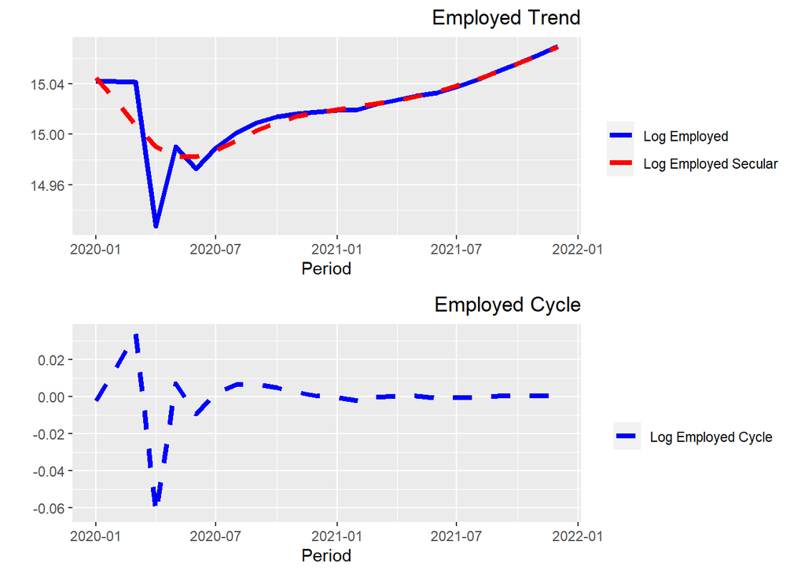

```r
plot_grid(plot5, plot6,ncol = 1,align = 'v')
```

#Arkansas

```r
lf_states5 <- filter(lf_states, Year != 2019, State == 5, early == 1)
lf_states5_6.25 <- hpfilter(lf_states5$lEmp , freq = 6.25,type = "lambda")
lf_states5$Emp_T6.25 <- lf_states5_6.25$trend
lf_states5$Emp_C6.25 <- lf_states5_6.25$cycle
plot7<-ggplot(data=lf_states5)+
geom_line(aes(x=Period,y=lEmp,color='Log Employed'),size=1.5) + geom_line(aes(x=Period,y=Emp_T6.25,color='Log Employed Secular'),linetype=2,size=1.5) +xlab("Period")+ylab("")+scale_colour_manual(name="",values=c('Log Employed'='blue','Log Employed Secular'='red'))+ggtitle('Employed Trend')+theme(plot.title = element_text(hjust = 1))

plot8<-ggplot(data=lf_states5)+
geom_line(aes(x=Period,y=Emp_C6.25,color='Log Employed Cycle'),size=1.5,linetype=2)  +xlab("Period")+ylab("")+scale_colour_manual(name="",values=c('Log Employed Cycle'='blue'))+ggtitle('Employed Cycle')+theme(plot.title = element_text(hjust = 1))
```

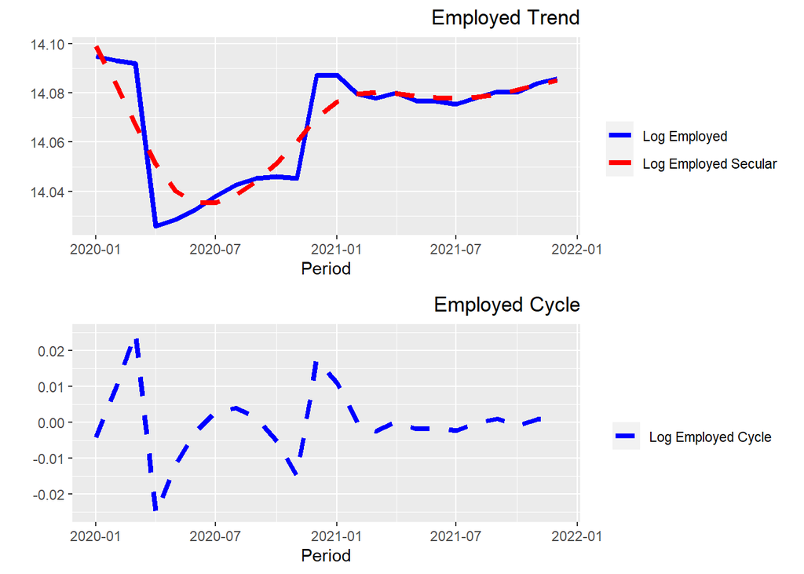

```r
plot_grid(plot7, plot8,ncol = 1,align = 'v')
```

#Florida

```r
lf_states12 <- filter(lf_states, Year != 2019, State == 12, early == 1)
lf_states12_6.25 <- hpfilter(lf_states12$lEmp , freq = 6.25,type = "lambda")
lf_states12$Emp_T6.25 <- lf_states12_6.25$trend
lf_states12$Emp_C6.25 <- lf_states12_6.25$cycle
plot9<-ggplot(data=lf_states12)+
geom_line(aes(x=Period,y=lEmp,color='Log Employed'),size=1.5) + geom_line(aes(x=Period,y=Emp_T6.25,color='Log Employed Secular'),linetype=2,size=1.5) +xlab("Period")+ylab("")+scale_colour_manual(name="",values=c('Log Employed'='blue','Log Employed Secular'='red'))+ggtitle('Employed Trend')+theme(plot.title = element_text(hjust = 1))

plot10<-ggplot(data=lf_states12)+
geom_line(aes(x=Period,y=Emp_C6.25,color='Log Employed Cycle'),size=1.5,linetype=2)  +xlab("Period")+ylab("")+scale_colour_manual(name="",values=c('Log Employed Cycle'='blue'))+ggtitle('Employed Cycle')+theme(plot.title = element_text(hjust = 1))
```

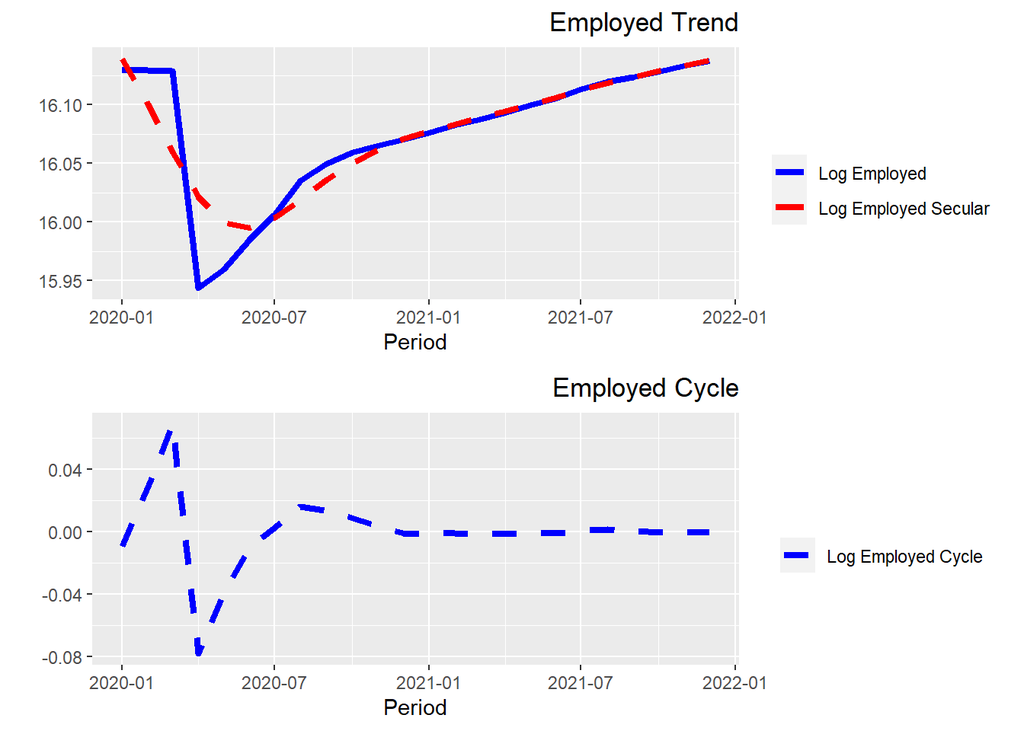

```r
plot_grid(plot9, plot10,ncol = 1,align = 'v')
```

#Georgia

```r
lf_states13 <- filter(lf_states, Year != 2019, State == 13, early == 1)
lf_states13_6.25 <- hpfilter(lf_states13$lEmp , freq = 6.25,type = "lambda")
lf_states13$Emp_T6.25 <- lf_states13_6.25$trend
lf_states13$Emp_C6.25 <- lf_states13_6.25$cycle
plot11<-ggplot(data=lf_states13)+
geom_line(aes(x=Period,y=lEmp,color='Log Employed'),size=1.5) + geom_line(aes(x=Period,y=Emp_T6.25,color='Log Employed Secular'),linetype=2,size=1.5) +xlab("Period")+ylab("")+scale_colour_manual(name="",values=c('Log Employed'='blue','Log Employed Secular'='red'))+ggtitle('Employed Trend')+theme(plot.title = element_text(hjust = 1))

plot12<-ggplot(data=lf_states13)+
geom_line(aes(x=Period,y=Emp_C6.25,color='Log Employed Cycle'),size=1.5,linetype=2)  +xlab("Period")+ylab("")+scale_colour_manual(name="",values=c('Log Employed Cycle'='blue'))+ggtitle('Employed Cycle')+theme(plot.title = element_text(hjust = 1))
```

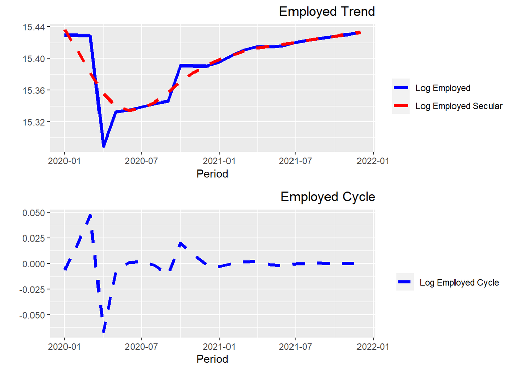

```r
plot_grid(plot11, plot12,ncol = 1,align = 'v')
```

#Idaho

```r
lf_states16 <- filter(lf_states, Year != 2019, State == 16, early == 1)
lf_states16_6.25 <- hpfilter(lf_states16$lEmp , freq = 6.25,type = "lambda")
lf_states16$Emp_T6.25 <- lf_states16_6.25$trend
lf_states16$Emp_C6.25 <- lf_states16_6.25$cycle
plot13<-ggplot(data=lf_states16)+
geom_line(aes(x=Period,y=lEmp,color='Log Employed'),size=1.5) + geom_line(aes(x=Period,y=Emp_T6.25,color='Log Employed Secular'),linetype=2,size=1.5) +xlab("Period")+ylab("")+scale_colour_manual(name="",values=c('Log Employed'='blue','Log Employed Secular'='red'))+ggtitle('Employed Trend')+theme(plot.title = element_text(hjust = 1))

plot14<-ggplot(data=lf_states16)+
geom_line(aes(x=Period,y=Emp_C6.25,color='Log Employed Cycle'),size=1.5,linetype=2)  +xlab("Period")+ylab("")+scale_colour_manual(name="",values=c('Log Employed Cycle'='blue'))+ggtitle('Employed Cycle')+theme(plot.title = element_text(hjust = 1))
```

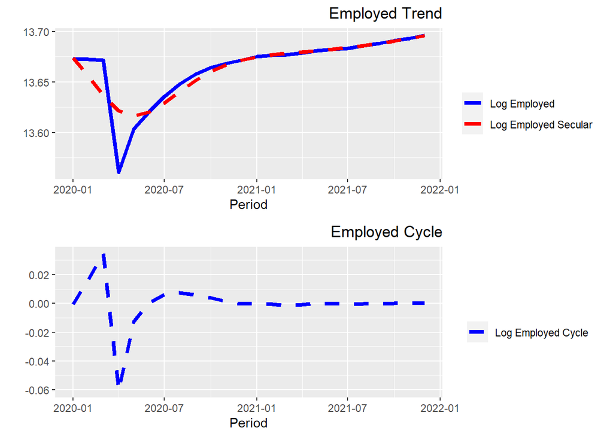

```r
plot_grid(plot13, plot14,ncol = 1,align = 'v')
```

#Indiana

```r
lf_states18 <- filter(lf_states, Year != 2019, State == 18, early == 1)
lf_states18_6.25 <- hpfilter(lf_states18$lEmp , freq = 6.25,type = "lambda")
lf_states18$Emp_T6.25 <- lf_states18_6.25$trend
lf_states18$Emp_C6.25 <- lf_states18_6.25$cycle
plot15<-ggplot(data=lf_states18)+
geom_line(aes(x=Period,y=lEmp,color='Log Employed'),size=1.5) + geom_line(aes(x=Period,y=Emp_T6.25,color='Log Employed Secular'),linetype=2,size=1.5) +xlab("Period")+ylab("")+scale_colour_manual(name="",values=c('Log Employed'='blue','Log Employed Secular'='red'))+ggtitle('Employed Trend')+theme(plot.title = element_text(hjust = 1))

plot16<-ggplot(data=lf_states18)+
geom_line(aes(x=Period,y=Emp_C6.25,color='Log Employed Cycle'),size=1.5,linetype=2)  +xlab("Period")+ylab("")+scale_colour_manual(name="",values=c('Log Employed Cycle'='blue'))+ggtitle('Employed Cycle')+theme(plot.title = element_text(hjust = 1))
```

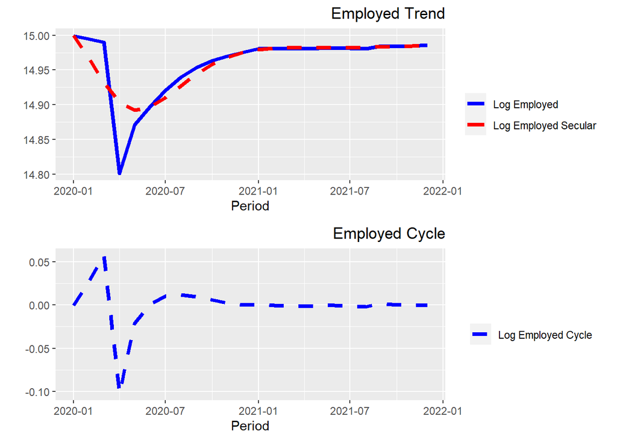

```r
plot_grid(plot15, plot16,ncol = 1,align = 'v')
```

#Iowa#

```r
lf_states19 <- filter(lf_states, Year != 2019, State == 19, early == 1)
lf_states19_6.25 <- hpfilter(lf_states19$lEmp , freq = 6.25,type = "lambda")
lf_states19$Emp_T6.25 <- lf_states19_6.25$trend
lf_states19$Emp_C6.25 <- lf_states19_6.25$cycle
plot17<-ggplot(data=lf_states19)+
geom_line(aes(x=Period,y=lEmp,color='Log Employed'),size=1.5) + geom_line(aes(x=Period,y=Emp_T6.25,color='Log Employed Secular'),linetype=2,size=1.5) +xlab("Period")+ylab("")+scale_colour_manual(name="",values=c('Log Employed'='blue','Log Employed Secular'='red'))+ggtitle('Employed Trend')+theme(plot.title = element_text(hjust = 1))

plot18<-ggplot(data=lf_states19)+
geom_line(aes(x=Period,y=Emp_C6.25,color='Log Employed Cycle'),size=1.5,linetype=2)  +xlab("Period")+ylab("")+scale_colour_manual(name="",values=c('Log Employed Cycle'='blue'))+ggtitle('Employed Cycle')+theme(plot.title = element_text(hjust = 1))
```

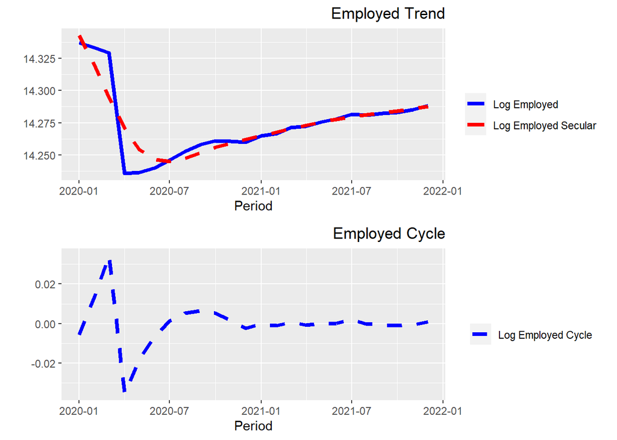

```r
plot_grid(plot17, plot18,ncol = 1,align = 'v')
```

#Maryland

```r
lf_states24 <- filter(lf_states, Year!= 2019, State == 24, early == 1)
lf_states24_6.25 <- hpfilter(lf_states24$lEmp , freq = 6.25,type = "lambda")
lf_states24$Emp_T6.25 <- lf_states24_6.25$trend
lf_states24$Emp_C6.25 <- lf_states24_6.25$cycle
plot19<-ggplot(data=lf_states24)+
geom_line(aes(x=Period,y=lEmp,color='Log Employed'),size=1.5) + geom_line(aes(x=Period,y=Emp_T6.25,color='Log Employed Secular'),linetype=2,size=1.5) +xlab("Period")+ylab("")+scale_colour_manual(name="",values=c('Log Employed'='blue','Log Employed Secular'='red'))+ggtitle('Employed Trend')+theme(plot.title = element_text(hjust = 1))

plot20<-ggplot(data=lf_states24)+
geom_line(aes(x=Period,y=Emp_C6.25,color='Log Employed Cycle'),size=1.5,linetype=2)  +xlab("Period")+ylab("")+scale_colour_manual(name="",values=c('Log Employed Cycle'='blue'))+ggtitle('Employed Cycle')+theme(plot.title = element_text(hjust = 1))
```

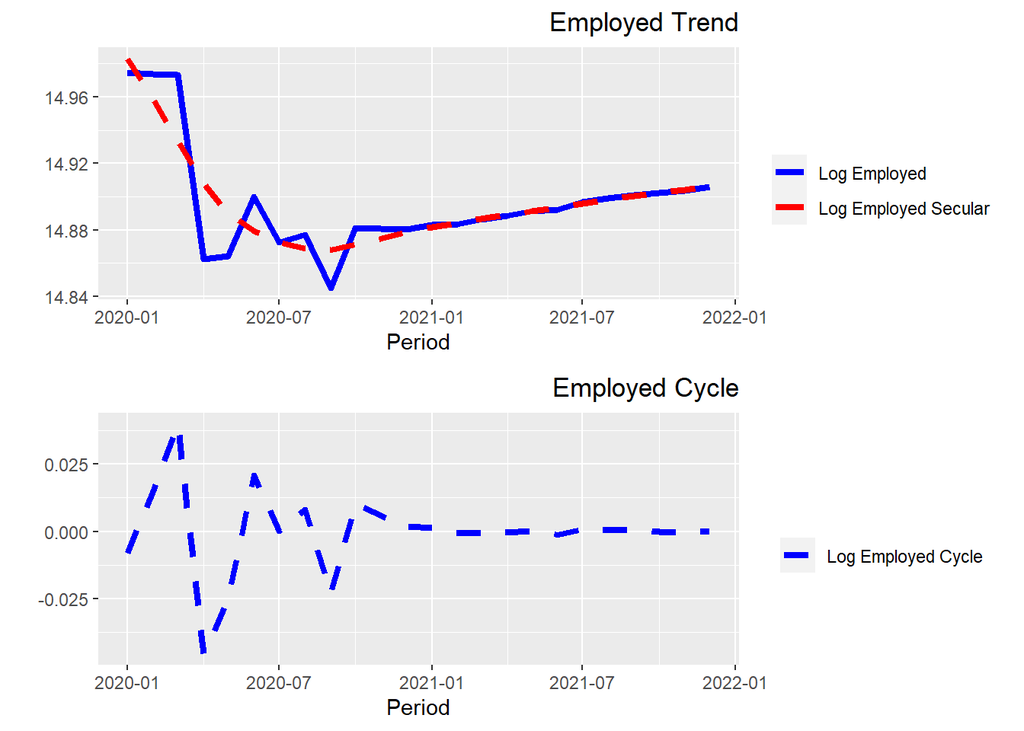

```r
plot_grid(plot19, plot20,ncol = 1,align = 'v')
```

#Mississippi

```r
lf_states28 <- filter(lf_states, Year != 2019, State == 28, early == 1)
lf_states28_6.25 <- hpfilter(lf_states28$lEmp , freq = 6.25,type = "lambda")
lf_states28$Emp_T6.25 <- lf_states28_6.25$trend
lf_states28$Emp_C6.25 <- lf_states28_6.25$cycle
plot21<-ggplot(data=lf_states28)+
geom_line(aes(x=Period,y=lEmp,color='Log Employed'),size=1.5) + geom_line(aes(x=Period,y=Emp_T6.25,color='Log Employed Secular'),linetype=2,size=1.5) +xlab("Period")+ylab("")+scale_colour_manual(name="",values=c('Log Employed'='blue','Log Employed Secular'='red'))+ggtitle('Employed Trend')+theme(plot.title = element_text(hjust = 1))

plot22<-ggplot(data=lf_states28)+
geom_line(aes(x=Period,y=Emp_C6.25,color='Log Employed Cycle'),size=1.5,linetype=2)  +xlab("Period")+ylab("")+scale_colour_manual(name="",values=c('Log Employed Cycle'='blue'))+ggtitle('Employed Cycle')+theme(plot.title = element_text(hjust = 1))
```

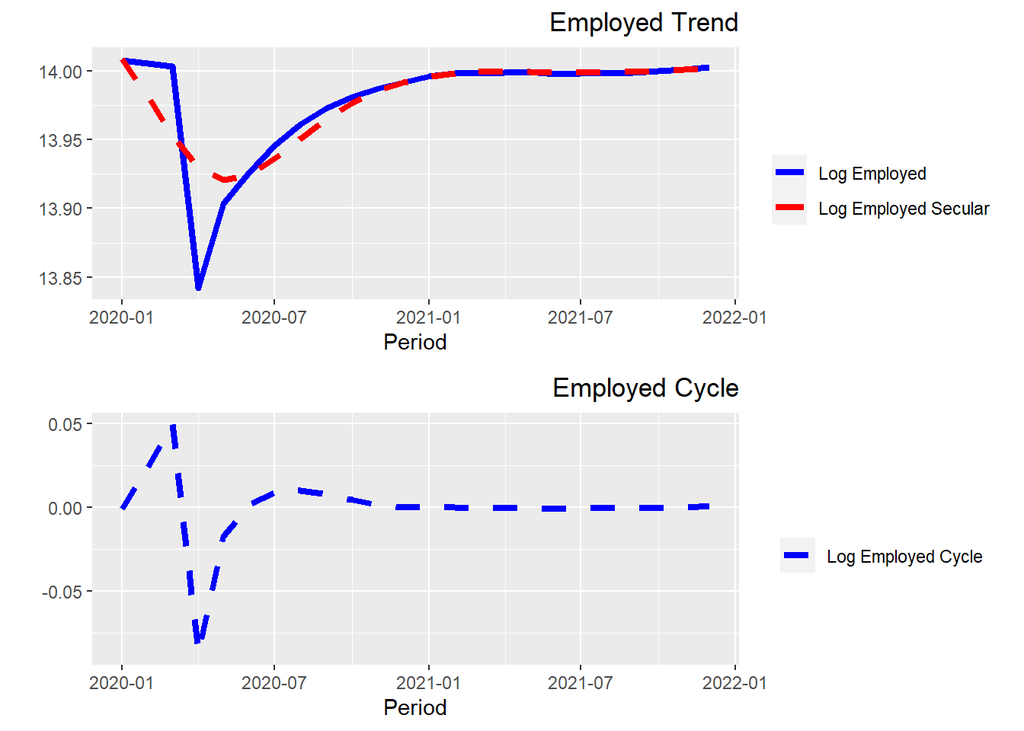

```r
plot_grid(plot21, plot22,ncol = 1,align = 'v')
```

#Missouri

```r
lf_states29 <- filter(lf_states, Year != 2019, State == 29, early == 1)
lf_states29_6.25 <- hpfilter(lf_states29$lEmp , freq = 6.25,type = "lambda")
lf_states29$Emp_T6.25 <- lf_states29_6.25$trend
lf_states29$Emp_C6.25 <- lf_states29_6.25$cycle
plot23<-ggplot(data=lf_states29)+
geom_line(aes(x=Period,y=lEmp,color='Log Employed'),size=1.5) + geom_line(aes(x=Period,y=Emp_T6.25,color='Log Employed Secular'),linetype=2,size=1.5) +xlab("Period")+ylab("")+scale_colour_manual(name="",values=c('Log Employed'='blue','Log Employed Secular'='red'))+ggtitle('Employed Trend')+theme(plot.title = element_text(hjust = 1))

plot24<-ggplot(data=lf_states29)+
geom_line(aes(x=Period,y=Emp_C6.25,color='Log Employed Cycle'),size=1.5,linetype=2)  +xlab("Period")+ylab("")+scale_colour_manual(name="",values=c('Log Employed Cycle'='blue'))+ggtitle('Employed Cycle')+theme(plot.title = element_text(hjust = 1))
```

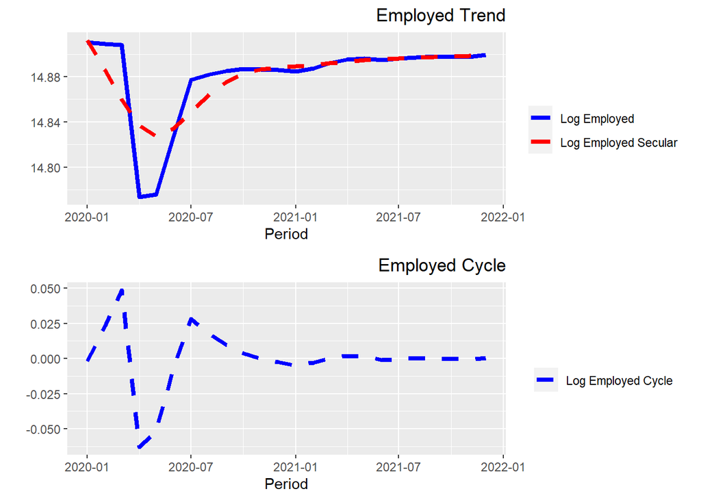

```r
plot_grid(plot23, plot24,ncol = 1,align = 'v')
```

#Montana

```r
lf_states30 <- filter(lf_states, Year != 2019, State == 30, early == 1)
lf_states30_6.25 <- hpfilter(lf_states30$lEmp , freq = 6.25,type = "lambda")
lf_states30$Emp_T6.25 <- lf_states30_6.25$trend
lf_states30$Emp_C6.25 <- lf_states30_6.25$cycle
plot25<-ggplot(data=lf_states30)+
geom_line(aes(x=Period,y=lEmp,color='Log Employed'),size=1.5) + geom_line(aes(x=Period,y=Emp_T6.25,color='Log Employed Secular'),linetype=2,size=1.5) +xlab("Period")+ylab("")+scale_colour_manual(name="",values=c('Log Employed'='blue','Log Employed Secular'='red'))+ggtitle('Employed Trend')+theme(plot.title = element_text(hjust = 1))

plot26<-ggplot(data=lf_states30)+
geom_line(aes(x=Period,y=Emp_C6.25,color='Log Employed Cycle'),size=1.5,linetype=2)  +xlab("Period")+ylab("")+scale_colour_manual(name="",values=c('Log Employed Cycle'='blue'))+ggtitle('Employed Cycle')+theme(plot.title = element_text(hjust = 1))
```

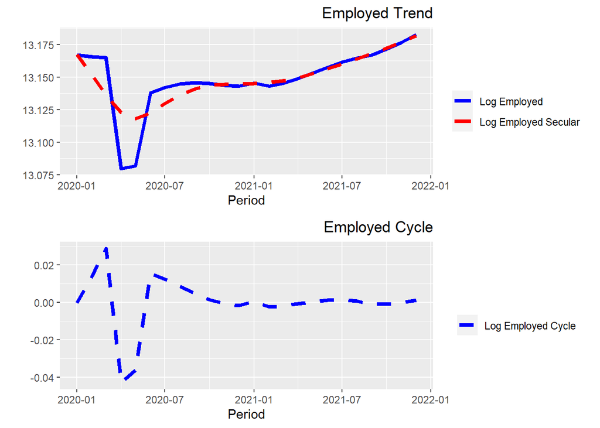

```r
plot_grid(plot25, plot26,ncol = 1,align = 'v')
```

#Nebraska

```r
lf_states31 <- filter(lf_states, Year != 2019, State == 31, early == 1)
lf_states31_6.25 <- hpfilter(lf_states31$lEmp , freq = 6.25,type = "lambda")
lf_states31$Emp_T6.25 <- lf_states31_6.25$trend
lf_states31$Emp_C6.25 <- lf_states31_6.25$cycle
plot27<-ggplot(data=lf_states31)+
geom_line(aes(x=Period,y=lEmp,color='Log Employed'),size=1.5) + geom_line(aes(x=Period,y=Emp_T6.25,color='Log Employed Secular'),linetype=2,size=1.5) +xlab("Period")+ylab("")+scale_colour_manual(name="",values=c('Log Employed'='blue','Log Employed Secular'='red'))+ggtitle('Employed Trend')+theme(plot.title = element_text(hjust = 1))

plot28<-ggplot(data=lf_states31)+
geom_line(aes(x=Period,y=Emp_C6.25,color='Log Employed Cycle'),size=1.5,linetype=2)  +xlab("Period")+ylab("")+scale_colour_manual(name="",values=c('Log Employed Cycle'='blue'))+ggtitle('Employed Cycle')+theme(plot.title = element_text(hjust = 1))
```

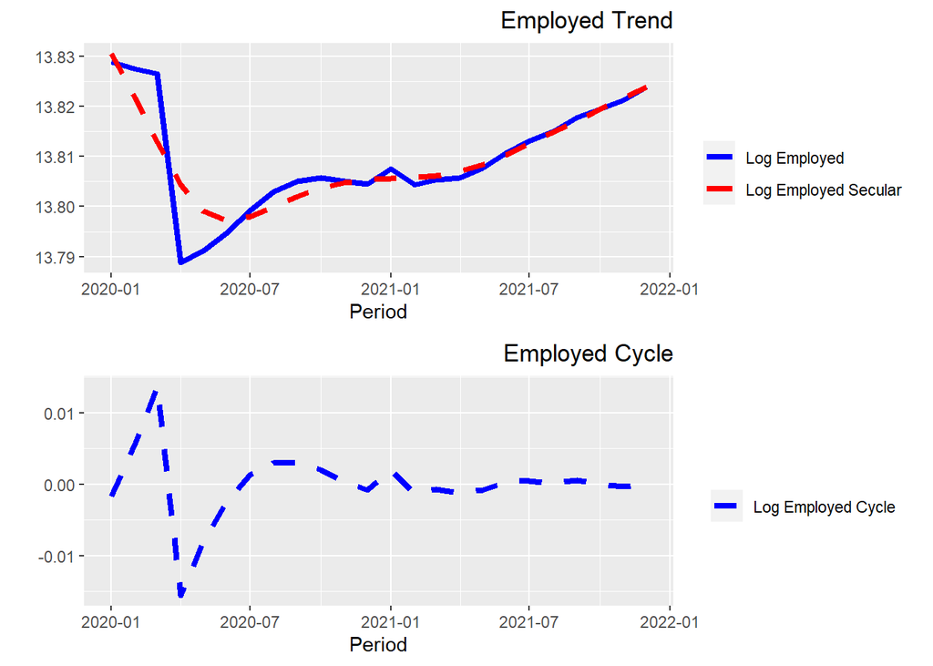

```r
plot_grid(plot27, plot28,ncol = 1,align = 'v')
```

#New Hampshire

```r
lf_states33 <- filter(lf_states, Year != 2019, State == 33, early == 1)
lf_states33_6.25 <- hpfilter(lf_states33$lEmp , freq = 6.25,type = "lambda")
lf_states33$Emp_T6.25 <- lf_states33_6.25$trend
lf_states33$Emp_C6.25 <- lf_states33_6.25$cycle
plot29<-ggplot(data=lf_states33)+
geom_line(aes(x=Period,y=lEmp,color='Log Employed'),size=1.5) + geom_line(aes(x=Period,y=Emp_T6.25,color='Log Employed Secular'),linetype=2,size=1.5) +xlab("Period")+ylab("")+scale_colour_manual(name="",values=c('Log Employed'='blue','Log Employed Secular'='red'))+ggtitle('Employed Trend')+theme(plot.title = element_text(hjust = 1))

plot30<-ggplot(data=lf_states33)+
geom_line(aes(x=Period,y=Emp_C6.25,color='Log Employed Cycle'),size=1.5,linetype=2)  +xlab("Period")+ylab("")+scale_colour_manual(name="",values=c('Log Employed Cycle'='blue'))+ggtitle('Employed Cycle')+theme(plot.title = element_text(hjust = 1))
```

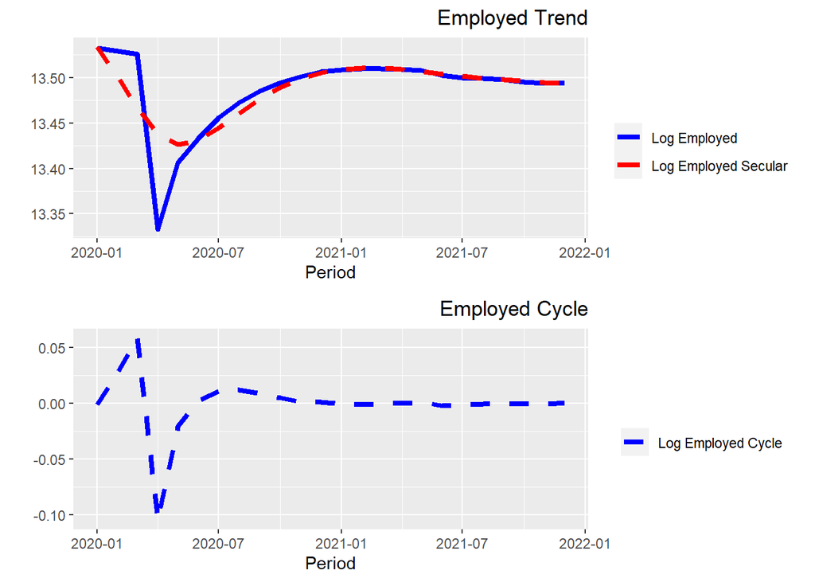

```r
plot_grid(plot29, plot30,ncol = 1,align = 'v')
```

#North Dakota

```r
lf_states38 <- filter(lf_states, Year != 2019, State == 38, early == 1)
lf_states38_6.25 <- hpfilter(lf_states38$lEmp , freq = 6.25,type = "lambda")
lf_states38$Emp_T6.25 <- lf_states38_6.25$trend
lf_states38$Emp_C6.25 <- lf_states38_6.25$cycle
plot31<-ggplot(data=lf_states38)+
geom_line(aes(x=Period,y=lEmp,color='Log Employed'),size=1.5) + geom_line(aes(x=Period,y=Emp_T6.25,color='Log Employed Secular'),linetype=2,size=1.5) +xlab("Period")+ylab("")+scale_colour_manual(name="",values=c('Log Employed'='blue','Log Employed Secular'='red'))+ggtitle('Employed Trend')+theme(plot.title = element_text(hjust = 1))

plot32<-ggplot(data=lf_states38)+
geom_line(aes(x=Period,y=Emp_C6.25,color='Log Employed Cycle'),size=1.5,linetype=2)  +xlab("Period")+ylab("")+scale_colour_manual(name="",values=c('Log Employed Cycle'='blue'))+ggtitle('Employed Cycle')+theme(plot.title = element_text(hjust = 1))
```

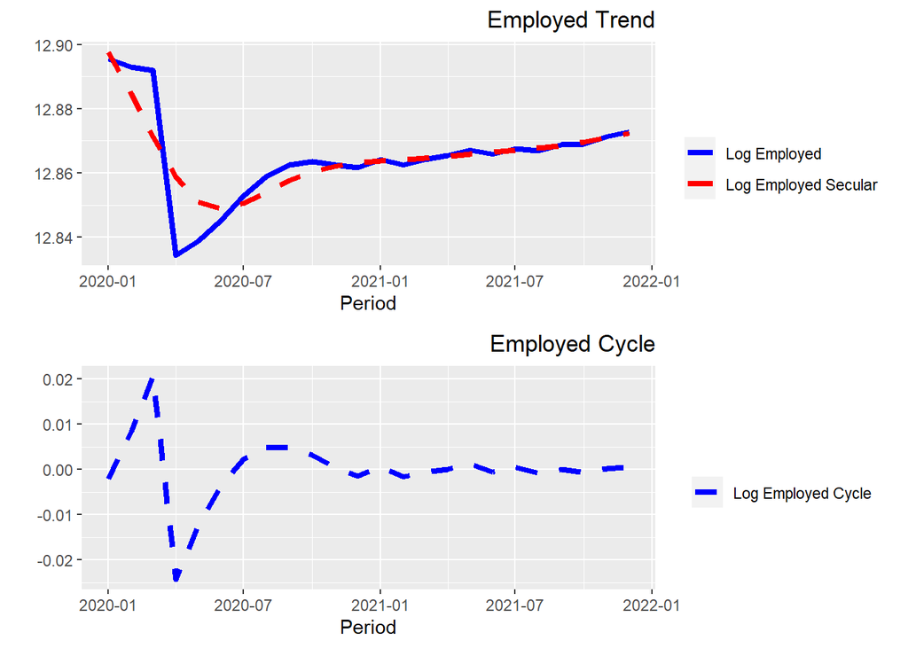

```r
plot_grid(plot31, plot32,ncol = 1,align = 'v')
```

#Ohio

```r
lf_states39 <- filter(lf_states, Year != 2019, State == 39, early == 1)
lf_states39_6.25 <- hpfilter(lf_states39$lEmp , freq = 6.25,type = "lambda")
lf_states39$Emp_T6.25 <- lf_states39_6.25$trend
lf_states39$Emp_C6.25 <- lf_states39_6.25$cycle
plot33<-ggplot(data=lf_states39)+
geom_line(aes(x=Period,y=lEmp,color='Log Employed'),size=1.5) + geom_line(aes(x=Period,y=Emp_T6.25,color='Log Employed Secular'),linetype=2,size=1.5) +xlab("Period")+ylab("")+scale_colour_manual(name="",values=c('Log Employed'='blue','Log Employed Secular'='red'))+ggtitle('Employed Trend')+theme(plot.title = element_text(hjust = 1))

plot34<-ggplot(data=lf_states39)+
geom_line(aes(x=Period,y=Emp_C6.25,color='Log Employed Cycle'),size=1.5,linetype=2)  +xlab("Period")+ylab("")+scale_colour_manual(name="",values=c('Log Employed Cycle'='blue'))+ggtitle('Employed Cycle')+theme(plot.title = element_text(hjust = 1))
```

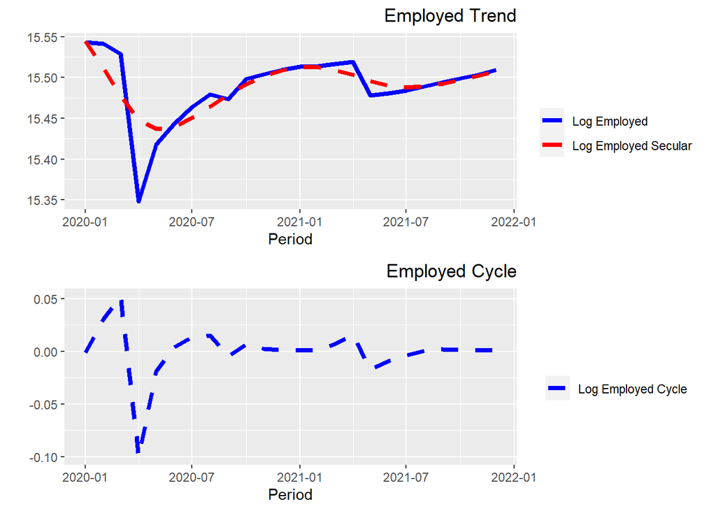

```r
plot_grid(plot33, plot34,ncol = 1,align = 'v')
```

#Oklahoma

```r
lf_states40 <- filter(lf_states, Year != 2019, State == 40, early == 1)
lf_states40_6.25 <- hpfilter(lf_states40$lEmp , freq = 6.25,type = "lambda")
lf_states40$Emp_T6.25 <- lf_states40_6.25$trend
lf_states40$Emp_C6.25 <- lf_states40_6.25$cycle
plot35<-ggplot(data=lf_states40)+
geom_line(aes(x=Period,y=lEmp,color='Log Employed'),size=1.5) + geom_line(aes(x=Period,y=Emp_T6.25,color='Log Employed Secular'),linetype=2,size=1.5) +xlab("Period")+ylab("")+scale_colour_manual(name="",values=c('Log Employed'='blue','Log Employed Secular'='red'))+ggtitle('Employed Trend')+theme(plot.title = element_text(hjust = 1))

plot36<-ggplot(data=lf_states40)+
geom_line(aes(x=Period,y=Emp_C6.25,color='Log Employed Cycle'),size=1.5,linetype=2)  +xlab("Period")+ylab("")+scale_colour_manual(name="",values=c('Log Employed Cycle'='blue'))+ggtitle('Employed Cycle')+theme(plot.title = element_text(hjust = 1))
```

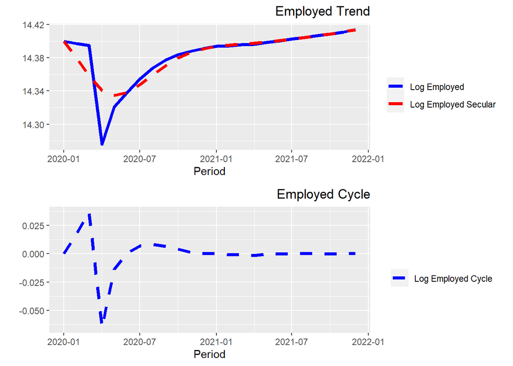

```r
plot_grid(plot35, plot36,ncol = 1,align = 'v')
```

#South Carolina

```r
lf_states45 <- filter(lf_states, Year != 2019, State == 45, early == 1)
lf_states45_6.25 <- hpfilter(lf_states45$lEmp , freq = 6.25,type = "lambda")
lf_states45$Emp_T6.25 <- lf_states45_6.25$trend
lf_states45$Emp_C6.25 <- lf_states45_6.25$cycle
plot37<-ggplot(data=lf_states45)+
geom_line(aes(x=Period,y=lEmp,color='Log Employed'),size=1.5) + geom_line(aes(x=Period,y=Emp_T6.25,color='Log Employed Secular'),linetype=2,size=1.5) +xlab("Period")+ylab("")+scale_colour_manual(name="",values=c('Log Employed'='blue','Log Employed Secular'='red'))+ggtitle('Employed Trend')+theme(plot.title = element_text(hjust = 1))

plot38<-ggplot(data=lf_states45)+
geom_line(aes(x=Period,y=Emp_C6.25,color='Log Employed Cycle'),size=1.5,linetype=2)  +xlab("Period")+ylab("")+scale_colour_manual(name="",values=c('Log Employed Cycle'='blue'))+ggtitle('Employed Cycle')+theme(plot.title = element_text(hjust = 1))
```

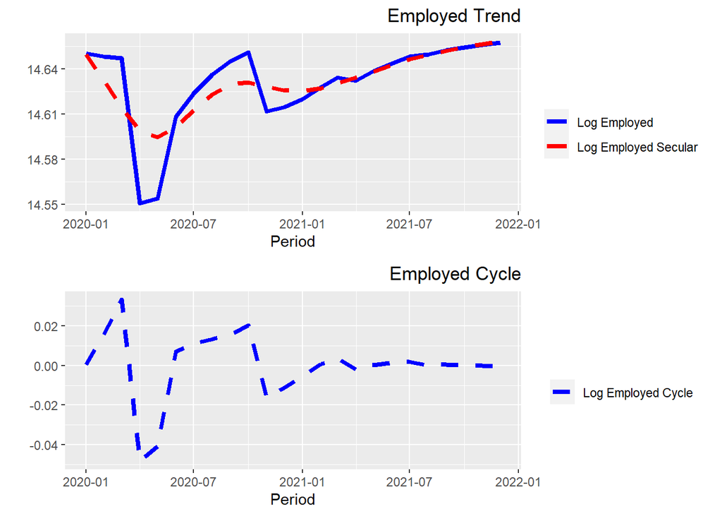

```r
plot_grid(plot37, plot38,ncol = 1,align = 'v')
```

#South Dakota

```r
lf_states46 <- filter(lf_states, Year != 2019, State == 46, early == 1)
lf_states46_6.25 <- hpfilter(lf_states46$lEmp , freq = 6.25,type = "lambda")
lf_states46$Emp_T6.25 <- lf_states46_6.25$trend
lf_states46$Emp_C6.25 <- lf_states46_6.25$cycle
plot39<-ggplot(data=lf_states46)+
geom_line(aes(x=Period,y=lEmp,color='Log Employed'),size=1.5) + geom_line(aes(x=Period,y=Emp_T6.25,color='Log Employed Secular'),linetype=2,size=1.5) +xlab("Period")+ylab("")+scale_colour_manual(name="",values=c('Log Employed'='blue','Log Employed Secular'='red'))+ggtitle('Employed Trend')+theme(plot.title = element_text(hjust = 1))

plot40<-ggplot(data=lf_states46)+
geom_line(aes(x=Period,y=Emp_C6.25,color='Log Employed Cycle'),size=1.5,linetype=2)  +xlab("Period")+ylab("")+scale_colour_manual(name="",values=c('Log Employed Cycle'='blue'))+ggtitle('Employed Cycle')+theme(plot.title = element_text(hjust = 1))
```

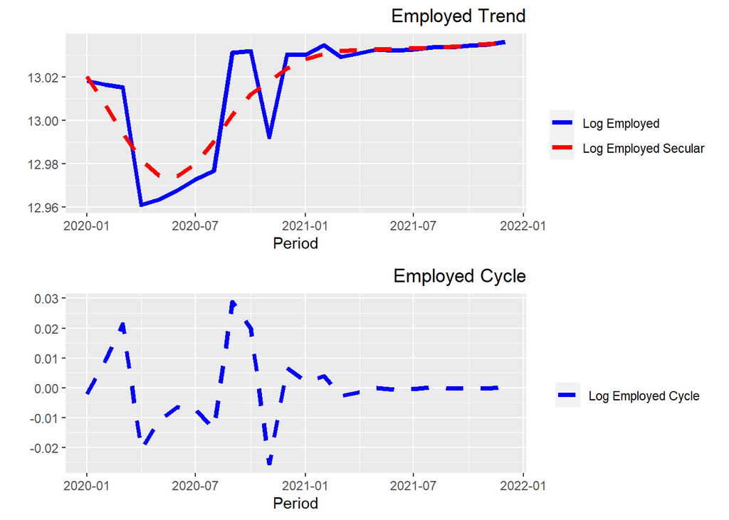

```r
plot_grid(plot39, plot40,ncol = 1,align = 'v')
```

#Tennessee

```r
lf_states47 <- filter(lf_states, Year != 2019, State == 47, early == 1)
lf_states47_6.25 <- hpfilter(lf_states47$lEmp , freq = 6.25,type = "lambda")
lf_states47$Emp_T6.25 <- lf_states47_6.25$trend
lf_states47$Emp_C6.25 <- lf_states47_6.25$cycle
plot41<-ggplot(data=lf_states47)+
geom_line(aes(x=Period,y=lEmp,color='Log Employed'),size=1.5) + geom_line(aes(x=Period,y=Emp_T6.25,color='Log Employed Secular'),linetype=2,size=1.5) +xlab("Period")+ylab("")+scale_colour_manual(name="",values=c('Log Employed'='blue','Log Employed Secular'='red'))+ggtitle('Employed Trend')+theme(plot.title = element_text(hjust = 1))

plot42<-ggplot(data=lf_states47)+
geom_line(aes(x=Period,y=Emp_C6.25,color='Log Employed Cycle'),size=1.5,linetype=2)  +xlab("Period")+ylab("")+scale_colour_manual(name="",values=c('Log Employed Cycle'='blue'))+ggtitle('Employed Cycle')+theme(plot.title = element_text(hjust = 1))
```

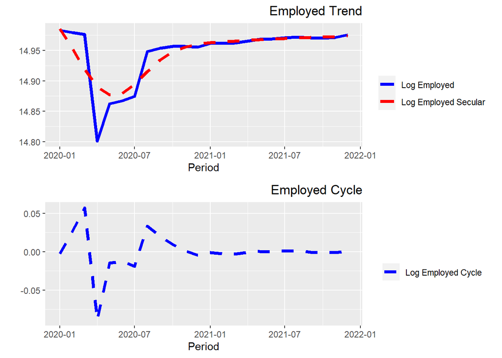

```r
plot_grid(plot41, plot42,ncol = 1,align = 'v')
```

#Texas

```r
lf_states48 <- filter(lf_states, Year != 2019, State == 48, early == 1)
lf_states48_6.25 <- hpfilter(lf_states48$lEmp , freq = 6.25,type = "lambda")
lf_states48$Emp_T6.25 <- lf_states48_6.25$trend
lf_states48$Emp_C6.25 <- lf_states48_6.25$cycle
plot43<-ggplot(data=lf_states48)+
geom_line(aes(x=Period,y=lEmp,color='Log Employed'),size=1.5) + geom_line(aes(x=Period,y=Emp_T6.25,color='Log Employed Secular'),linetype=2,size=1.5) +xlab("Period")+ylab("")+scale_colour_manual(name="",values=c('Log Employed'='blue','Log Employed Secular'='red'))+ggtitle('Employed Trend')+theme(plot.title = element_text(hjust = 1))

plot44<-ggplot(data=lf_states48)+
geom_line(aes(x=Period,y=Emp_C6.25,color='Log Employed Cycle'),size=1.5,linetype=2)  +xlab("Period")+ylab("")+scale_colour_manual(name="",values=c('Log Employed Cycle'='blue'))+ggtitle('Employed Cycle')+theme(plot.title = element_text(hjust = 1))
```

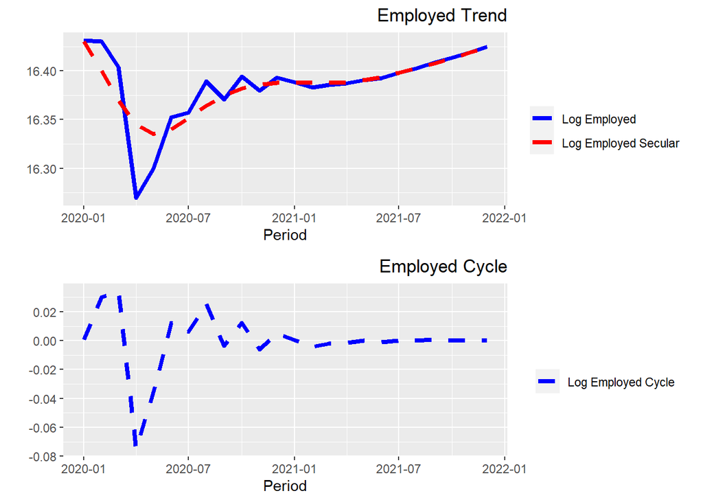

```r
plot_grid(plot43, plot44,ncol = 1,align = 'v')
```

#Utah

```r
lf_states49 <- filter(lf_states, Year != 2019, State == 49, early == 1)
lf_states49_6.25 <- hpfilter(lf_states49$lEmp , freq = 6.25,type = "lambda")
lf_states49$Emp_T6.25 <- lf_states49_6.25$trend
lf_states49$Emp_C6.25 <- lf_states49_6.25$cycle
plot45<-ggplot(data=lf_states49)+
geom_line(aes(x=Period,y=lEmp,color='Log Employed'),size=1.5) + geom_line(aes(x=Period,y=Emp_T6.25,color='Log Employed Secular'),linetype=2,size=1.5) +xlab("Period")+ylab("")+scale_colour_manual(name="",values=c('Log Employed'='blue','Log Employed Secular'='red'))+ggtitle('Employed Trend')+theme(plot.title = element_text(hjust = 1))

plot46<-ggplot(data=lf_states49)+
geom_line(aes(x=Period,y=Emp_C6.25,color='Log Employed Cycle'),size=1.5,linetype=2)  +xlab("Period")+ylab("")+scale_colour_manual(name="",values=c('Log Employed Cycle'='blue'))+ggtitle('Employed Cycle')+theme(plot.title = element_text(hjust = 1))
```

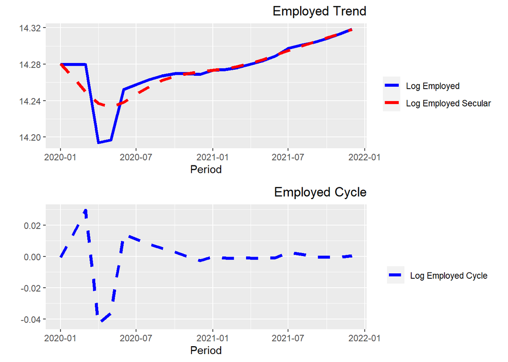

```r
plot_grid(plot45, plot46,ncol = 1,align = 'v')
```

#West Virginia

```r
lf_states54 <- filter(lf_states, Year != 2019, State == 54, early == 1)
lf_states54_6.25 <- hpfilter(lf_states54$lEmp , freq = 6.25,type = "lambda")
lf_states54$Emp_T6.25 <- lf_states54_6.25$trend
lf_states54$Emp_C6.25 <- lf_states54_6.25$cycle
plot47<-ggplot(data=lf_states54)+
geom_line(aes(x=Period,y=lEmp,color='Log Employed'),size=1.5) + geom_line(aes(x=Period,y=Emp_T6.25,color='Log Employed Secular'),linetype=2,size=1.5) +xlab("Period")+ylab("")+scale_colour_manual(name="",values=c('Log Employed'='blue','Log Employed Secular'='red'))+ggtitle('Employed Trend')+theme(plot.title = element_text(hjust = 1))

plot48<-ggplot(data=lf_states54)+
geom_line(aes(x=Period,y=Emp_C6.25,color='Log Employed Cycle'),size=1.5,linetype=2)  +xlab("Period")+ylab("")+scale_colour_manual(name="",values=c('Log Employed Cycle'='blue'))+ggtitle('Employed Cycle')+theme(plot.title = element_text(hjust = 1))
```

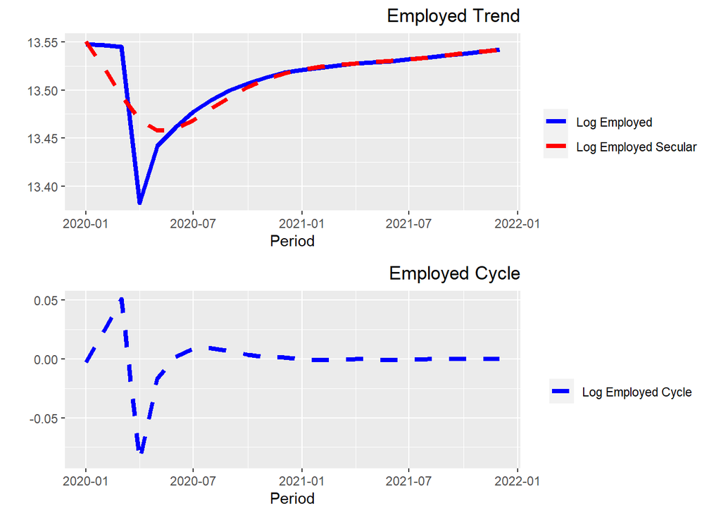

```r
plot_grid(plot47, plot48,ncol = 1,align = 'v')
```

#Wyoming

```r
lf_states56 <- filter(lf_states, Year != 2019, State == 56, early == 1)
lf_states56_6.25 <- hpfilter(lf_states56$lEmp , freq = 6.25,type = "lambda")
lf_states56$Emp_T6.25 <- lf_states56_6.25$trend
lf_states56$Emp_C6.25 <- lf_states56_6.25$cycle
plot49<-ggplot(data=lf_states56)+
geom_line(aes(x=Period,y=lEmp,color='Log Employed'),size=1.5) + geom_line(aes(x=Period,y=Emp_T6.25,color='Log Employed Secular'),linetype=2,size=1.5) +xlab("Period")+ylab("")+scale_colour_manual(name="",values=c('Log Employed'='blue','Log Employed Secular'='red'))+ggtitle('Employed Trend')+theme(plot.title = element_text(hjust = 1))

plot50<-ggplot(data=lf_states56)+
geom_line(aes(x=Period,y=Emp_C6.25,color='Log Employed Cycle'),size=1.5,linetype=2)  +xlab("Period")+ylab("")+scale_colour_manual(name="",values=c('Log Employed Cycle'='blue'))+ggtitle('Employed Cycle')+theme(plot.title = element_text(hjust = 1))
```

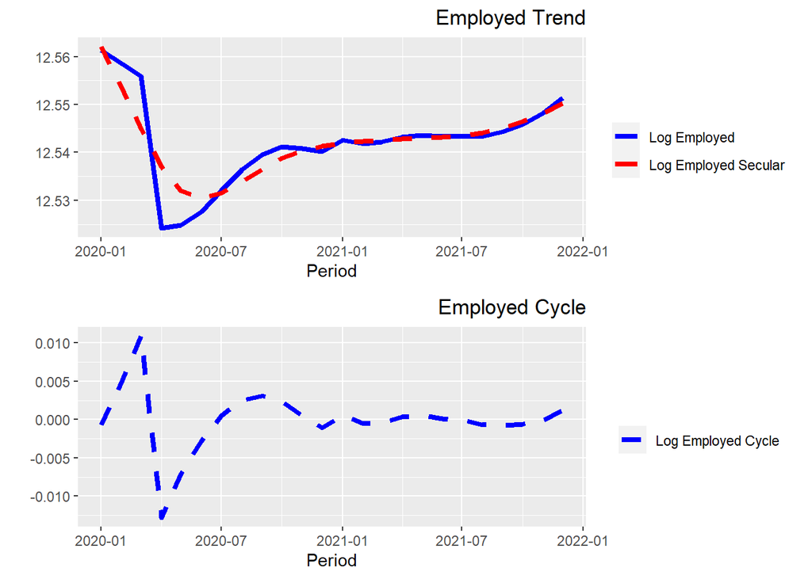

```r
plot_grid(plot49, plot50,ncol = 1,align = 'v')
```

#Graph the Trend and Cycle for 25 states which ends the UI policy on Sep.2021#

#California

```r
lf_states6 <- filter(lf_states, Year != 2019, State == 6, early == 0)
lf_states6_6.25 <- hpfilter(lf_states6$lEmp , freq = 6.25,type = "lambda")
lf_states6$Emp_T6.25 <- lf_states6_6.25$trend
lf_states6$Emp_C6.25 <- lf_states6_6.25$cycle
plot51<-ggplot(data=lf_states6)+
geom_line(aes(x=Period,y=lEmp,color='Log Employed'),size=1.5) + geom_line(aes(x=Period,y=Emp_T6.25,color='Log Employed Secular'),linetype=2,size=1.5) +xlab("Period")+ylab("")+scale_colour_manual(name="",values=c('Log Employed'='blue','Log Employed Secular'='red'))+ggtitle('Employed Trend')+theme(plot.title = element_text(hjust = 1))

plot52<-ggplot(data=lf_states6)+
geom_line(aes(x=Period,y=Emp_C6.25,color='Log Employed Cycle'),size=1.5,linetype=2)  +xlab("Period")+ylab("")+scale_colour_manual(name="",values=c('Log Employed Cycle'='blue'))+ggtitle('Employed Cycle')+theme(plot.title = element_text(hjust = 1))
```

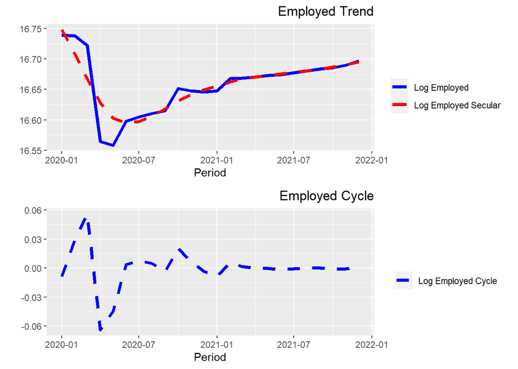

```r
plot_grid(plot51, plot52,ncol = 1,align = 'v')
```

#Colorado

```r
lf_states8 <- filter(lf_states, Year != 2019, State == 8, early == 0)
lf_states8_6.25 <- hpfilter(lf_states8$lEmp , freq = 6.25,type = "lambda")
lf_states8$Emp_T6.25 <- lf_states8_6.25$trend
lf_states8$Emp_C6.25 <- lf_states8_6.25$cycle
plot53<-ggplot(data=lf_states8)+
geom_line(aes(x=Period,y=lEmp,color='Log Employed'),size=1.5) + geom_line(aes(x=Period,y=Emp_T6.25,color='Log Employed Secular'),linetype=2,size=1.5) +xlab("Period")+ylab("")+scale_colour_manual(name="",values=c('Log Employed'='blue','Log Employed Secular'='red'))+ggtitle('Employed Trend')+theme(plot.title = element_text(hjust = 1))

plot54<-ggplot(data=lf_states8)+
geom_line(aes(x=Period,y=Emp_C6.25,color='Log Employed Cycle'),size=1.5,linetype=2)  +xlab("Period")+ylab("")+scale_colour_manual(name="",values=c('Log Employed Cycle'='blue'))+ggtitle('Employed Cycle')+theme(plot.title = element_text(hjust = 1))
```

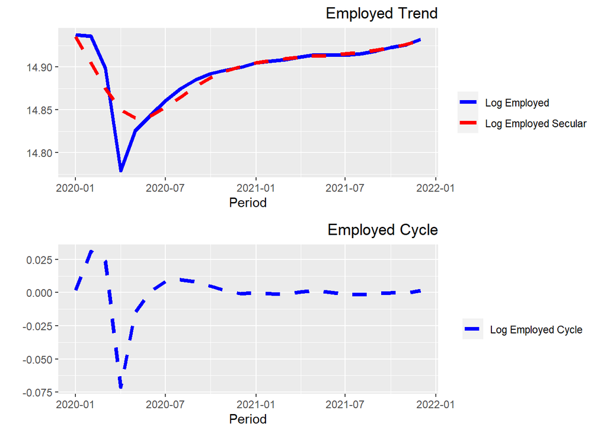

```r
plot_grid(plot53, plot54,ncol = 1,align = 'v')
```

#Connecticut

```r
lf_states9 <- filter(lf_states, Year != 2019, State == 9, early == 0)
lf_states9_6.25 <- hpfilter(lf_states9$lEmp , freq = 6.25,type = "lambda")
lf_states9$Emp_T6.25 <- lf_states9_6.25$trend
lf_states9$Emp_C6.25 <- lf_states9_6.25$cycle
plot55<-ggplot(data=lf_states9)+
geom_line(aes(x=Period,y=lEmp,color='Log Employed'),size=1.5) + geom_line(aes(x=Period,y=Emp_T6.25,color='Log Employed Secular'),linetype=2,size=1.5) +xlab("Period")+ylab("")+scale_colour_manual(name="",values=c('Log Employed'='blue','Log Employed Secular'='red'))+ggtitle('Employed Trend')+theme(plot.title = element_text(hjust = 1))

plot56<-ggplot(data=lf_states9)+
geom_line(aes(x=Period,y=Emp_C6.25,color='Log Employed Cycle'),size=1.5,linetype=2)  +xlab("Period")+ylab("")+scale_colour_manual(name="",values=c('Log Employed Cycle'='blue'))+ggtitle('Employed Cycle')+theme(plot.title = element_text(hjust = 1))
```

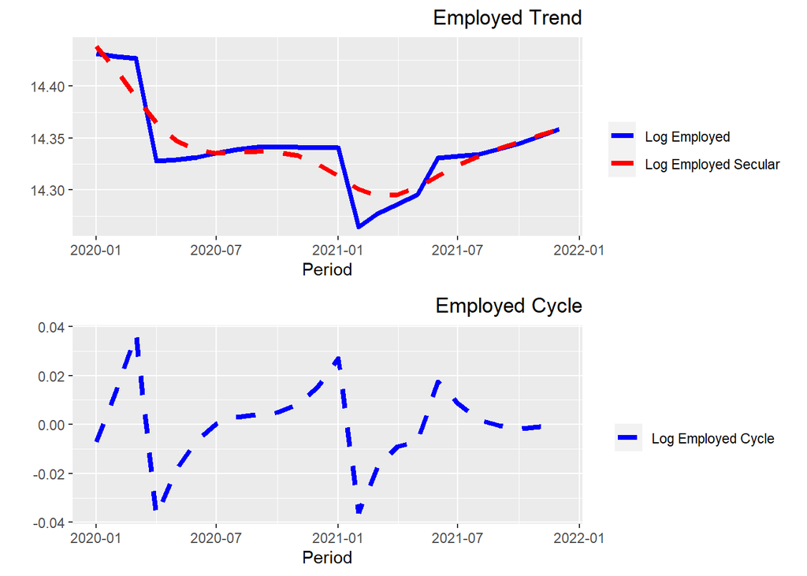

```r
plot_grid(plot55, plot56,ncol = 1,align = 'v')
```

#Delaware

```r
lf_states10 <- filter(lf_states, Year != 2019, State == 10, early == 0)
lf_states10_6.25 <- hpfilter(lf_states10$lEmp , freq = 6.25,type = "lambda")
lf_states10$Emp_T6.25 <- lf_states10_6.25$trend
lf_states10$Emp_C6.25 <- lf_states10_6.25$cycle
plot57<-ggplot(data=lf_states10)+
geom_line(aes(x=Period,y=lEmp,color='Log Employed'),size=1.5) + geom_line(aes(x=Period,y=Emp_T6.25,color='Log Employed Secular'),linetype=2,size=1.5) +xlab("Period")+ylab("")+scale_colour_manual(name="",values=c('Log Employed'='blue','Log Employed Secular'='red'))+ggtitle('Employed Trend')+theme(plot.title = element_text(hjust = 1))

plot58<-ggplot(data=lf_states10)+
geom_line(aes(x=Period,y=Emp_C6.25,color='Log Employed Cycle'),size=1.5,linetype=2)  +xlab("Period")+ylab("")+scale_colour_manual(name="",values=c('Log Employed Cycle'='blue'))+ggtitle('Employed Cycle')+theme(plot.title = element_text(hjust = 1))
```

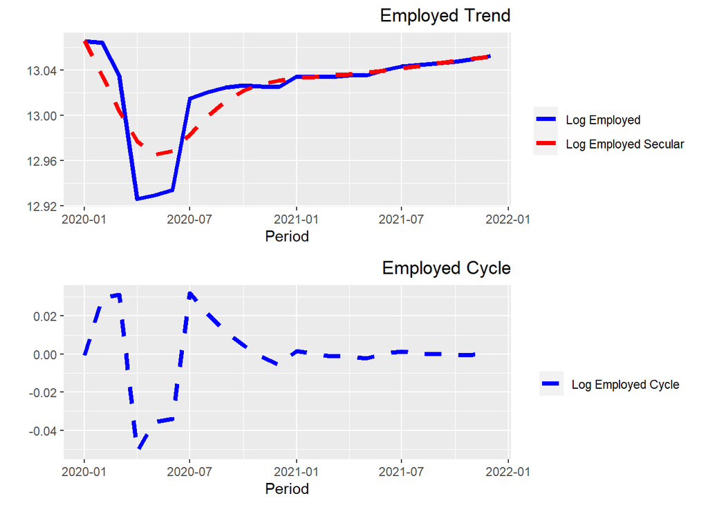

```r
plot_grid(plot57, plot58,ncol = 1,align = 'v')
```

#DISTRICT OF COLUMBIA

```r
lf_states11 <- filter(lf_states, Year != 2019, State == 11, early == 0)
lf_states11_6.25 <- hpfilter(lf_states11$lEmp , freq = 6.25,type = "lambda")
lf_states11$Emp_T6.25 <- lf_states11_6.25$trend
lf_states11$Emp_C6.25 <- lf_states11_6.25$cycle
plot59<-ggplot(data=lf_states11)+
geom_line(aes(x=Period,y=lEmp,color='Log Employed'),size=1.5) + geom_line(aes(x=Period,y=Emp_T6.25,color='Log Employed Secular'),linetype=2,size=1.5) +xlab("Period")+ylab("")+scale_colour_manual(name="",values=c('Log Employed'='blue','Log Employed Secular'='red'))+ggtitle('Employed Trend')+theme(plot.title = element_text(hjust = 1))

plot60<-ggplot(data=lf_states11)+
geom_line(aes(x=Period,y=Emp_C6.25,color='Log Employed Cycle'),size=1.5,linetype=2)  +xlab("Period")+ylab("")+scale_colour_manual(name="",values=c('Log Employed Cycle'='blue'))+ggtitle('Employed Cycle')+theme(plot.title = element_text(hjust = 1))
```

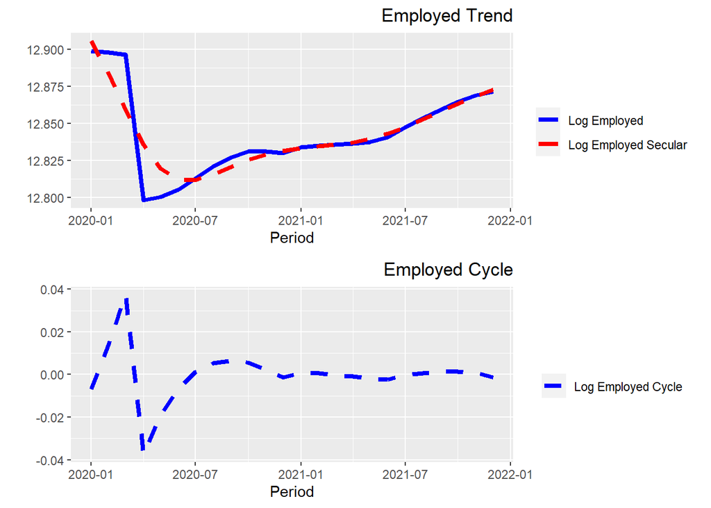

```r
plot_grid(plot59, plot60,ncol = 1,align = 'v')
```

#HAWAII

```r
lf_states15 <- filter(lf_states, Year != 2019, State == 15, early == 0)
lf_states15_6.25 <- hpfilter(lf_states15$lEmp , freq = 6.25,type = "lambda")
lf_states15$Emp_T6.25 <- lf_states15_6.25$trend
lf_states15$Emp_C6.25 <- lf_states15_6.25$cycle
plot61<-ggplot(data=lf_states15)+
geom_line(aes(x=Period,y=lEmp,color='Log Employed'),size=1.5) + geom_line(aes(x=Period,y=Emp_T6.25,color='Log Employed Secular'),linetype=2,size=1.5) +xlab("Period")+ylab("")+scale_colour_manual(name="",values=c('Log Employed'='blue','Log Employed Secular'='red'))+ggtitle('Employed Trend')+theme(plot.title = element_text(hjust = 1))

plot62<-ggplot(data=lf_states15)+
geom_line(aes(x=Period,y=Emp_C6.25,color='Log Employed Cycle'),size=1.5,linetype=2)  +xlab("Period")+ylab("")+scale_colour_manual(name="",values=c('Log Employed Cycle'='blue'))+ggtitle('Employed Cycle')+theme(plot.title = element_text(hjust = 1))
```

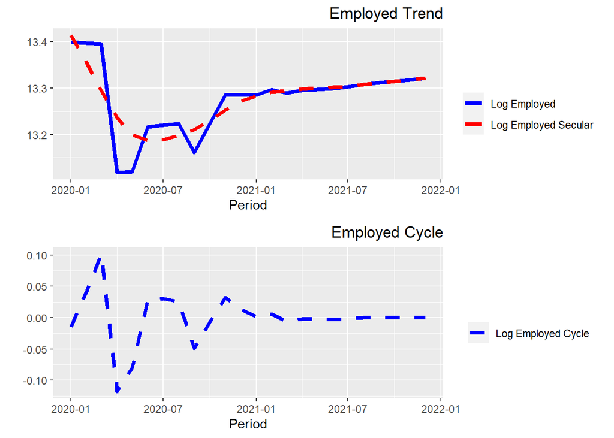

```r
plot_grid(plot61, plot62,ncol = 1,align = 'v')
```

#ILLINOIS

```r
lf_states17 <- filter(lf_states, Year != 2019, State == 17, early == 0)
lf_states17_6.25 <- hpfilter(lf_states17$lEmp , freq = 6.25,type = "lambda")
lf_states17$Emp_T6.25 <- lf_states17_6.25$trend
lf_states17$Emp_C6.25 <- lf_states17_6.25$cycle
plot63<-ggplot(data=lf_states17)+
geom_line(aes(x=Period,y=lEmp,color='Log Employed'),size=1.5) + geom_line(aes(x=Period,y=Emp_T6.25,color='Log Employed Secular'),linetype=2,size=1.5) +xlab("Period")+ylab("")+scale_colour_manual(name="",values=c('Log Employed'='blue','Log Employed Secular'='red'))+ggtitle('Employed Trend')+theme(plot.title = element_text(hjust = 1))

plot64<-ggplot(data=lf_states17)+
geom_line(aes(x=Period,y=Emp_C6.25,color='Log Employed Cycle'),size=1.5,linetype=2)  +xlab("Period")+ylab("")+scale_colour_manual(name="",values=c('Log Employed Cycle'='blue'))+ggtitle('Employed Cycle')+theme(plot.title = element_text(hjust = 1))
```

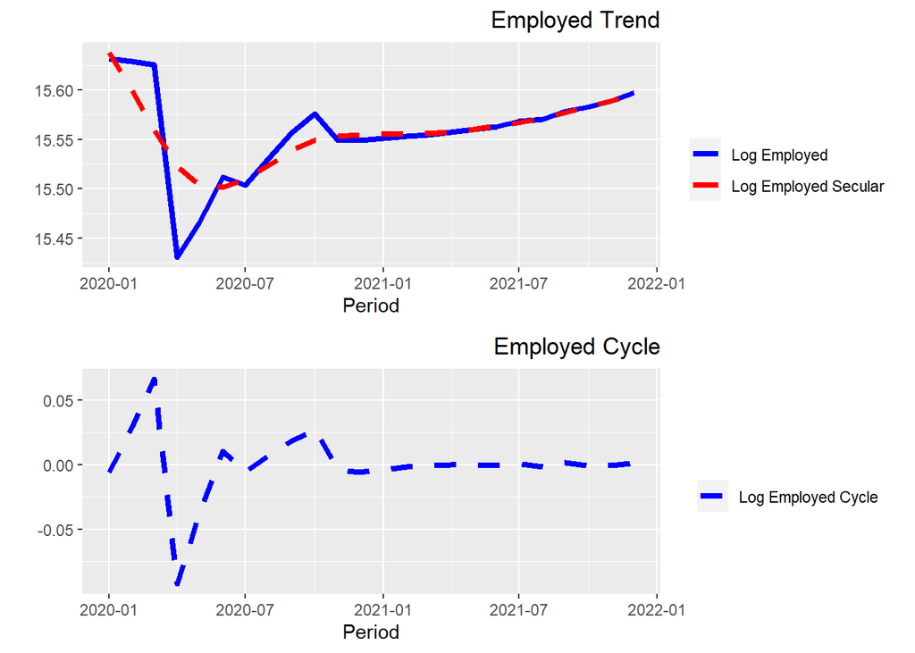

```r
plot_grid(plot63, plot64,ncol = 1,align = 'v')
```

#KANSAS

```r
lf_states20 <- filter(lf_states, Year != 2019, State == 20, early == 0)
lf_states20_6.25 <- hpfilter(lf_states20$lEmp , freq = 6.25,type = "lambda")
lf_states20$Emp_T6.25 <- lf_states20_6.25$trend
lf_states20$Emp_C6.25 <- lf_states20_6.25$cycle
plot65<-ggplot(data=lf_states20)+
geom_line(aes(x=Period,y=lEmp,color='Log Employed'),size=1.5) + geom_line(aes(x=Period,y=Emp_T6.25,color='Log Employed Secular'),linetype=2,size=1.5) +xlab("Period")+ylab("")+scale_colour_manual(name="",values=c('Log Employed'='blue','Log Employed Secular'='red'))+ggtitle('Employed Trend')+theme(plot.title = element_text(hjust = 1))

plot66<-ggplot(data=lf_states20)+
geom_line(aes(x=Period,y=Emp_C6.25,color='Log Employed Cycle'),size=1.5,linetype=2)  +xlab("Period")+ylab("")+scale_colour_manual(name="",values=c('Log Employed Cycle'='blue'))+ggtitle('Employed Cycle')+theme(plot.title = element_text(hjust = 1))
```